# Dominance–diversity relationships in ant communities differ with invasion - Arnan - 2018 - Global Change Biology - Wiley Online Library

[Global Change Biology](https://onlinelibrary.wiley.com/journal/13652486)

[Volume 24, Issue 10](https://onlinelibrary.wiley.com/toc/13652486/2018/24/10) p. 4614-4625

[figure not shown]

PRIMARY RESEARCH ARTICLE

Full Access

# Dominance–diversity relationships in ant communities differ with invasion

[Xavier Arnan](https://onlinelibrary.wiley.com/action/doSearch?ContribAuthorStored=Arnan%2C+Xavier)

[Alan N. Andersen](https://onlinelibrary.wiley.com/action/doSearch?ContribAuthorStored=Andersen%2C+Alan+N)

[Heloise Gibb](https://onlinelibrary.wiley.com/action/doSearch?ContribAuthorStored=Gibb%2C+Heloise)

[Catherine L. Parr](https://onlinelibrary.wiley.com/action/doSearch?ContribAuthorStored=Parr%2C+Catherine+L)

[Nathan J. Sanders](https://onlinelibrary.wiley.com/action/doSearch?ContribAuthorStored=Sanders%2C+Nathan+J)

[Robert R. Dunn](https://onlinelibrary.wiley.com/action/doSearch?ContribAuthorStored=Dunn%2C+Robert+R)

[Elena Angulo](https://onlinelibrary.wiley.com/action/doSearch?ContribAuthorStored=Angulo%2C+Elena)

[Fabricio B. Baccaro](https://onlinelibrary.wiley.com/action/doSearch?ContribAuthorStored=Baccaro%2C+Fabricio+B)

[Tom R. Bishop](https://onlinelibrary.wiley.com/action/doSearch?ContribAuthorStored=Bishop%2C+Tom+R)

[Raphaël Boulay](https://onlinelibrary.wiley.com/action/doSearch?ContribAuthorStored=Boulay%2C+Rapha%C3%ABl)

First published: 30 May 2018

https://doi.org/10.1111/gcb.14331

## Abstract

The relationship between levels of dominance and species richness is highly contentious, especially in ant communities. The dominance‐impoverishment rule states that high levels of dominance only occur in species‐poor communities, but there appear to be many cases of high levels of dominance in highly diverse communities. The extent to which dominant species limit local richness through competitive exclusion remains unclear, but such exclusion appears more apparent for non‐native rather than native dominant species. Here we perform the first global analysis of the relationship between behavioral dominance and species richness. We used data from 1,293 local assemblages of ground‐dwelling ants distributed across five continents to document the generality of the dominance‐impoverishment rule, and to identify the biotic and abiotic conditions under which it does and does not apply. We found that the behavioral dominance–diversity relationship varies greatly, and depends on whether dominant species are native or non‐native, whether dominance is considered as occurrence or relative abundance, and on variation in mean annual temperature. There were declines in diversity with increasing dominance in invaded communities, but diversity increased with increasing dominance in native communities. These patterns occur along the global temperature gradient. However, positive and negative relationships are strongest in the hottest sites. We also found that climate regulates the degree of behavioral dominance, but differently from how it shapes species richness. Our findings imply that, despite strong competitive interactions among ants, competitive exclusion is not a major driver of local richness in native ant communities. Although the dominance‐impoverishment rule applies to invaded communities, we propose an alternative dominance‐diversification rule for native communities.

## 1 INTRODUCTION

Understanding the factors that drive variation in local species richness at different spatial and temporal scales remains a fundamental challenge to community ecology (Chesson, 2000; Kneitel & Chase, 2004; Ricklefs, 1987). Regional species pools are determined by evolutionary and historical factors, while environmental filtering and dispersal barriers set the limit on the species that might potentially occur in a local community (Cornell & Harrison, 2014). The final realized diversity of communities then depends on local biotic interactions such as competition (Silvertown, Dodd, Gowing, Lawson, & McConway, 2006). The relative importance of competition is thought to vary predictably with environmental stress and disturbance, both of which constrain the capacity of dominant species to achieve levels of resource monopolization that lead to the exclusion of other species (Connell, 1978; Grime, 1979).

The stress‐disturbance‐competition framework was originally developed for communities of plants (Grime, 1979) and other sessile organisms (Connell, 1978), and has also been applied to macroscale analyses of the dynamics of ant communities (Andersen, 1995, 1997a). Like plants, ants are principally central‐place foragers whose foraging modules ramify in the environment to an extent that allows resource monopolization, leading to higher levels of competition than is the case for many other faunal groups (Andersen, 1991). Behavioral dominant species are aggressive species that are capable of exerting a strong influence on other species (Cerdá, Arnan, & Retana, 2013). The primary factors limiting ant productivity and the abundance of behaviorally dominant species are considered to be temperature (including a requirement of direct solar radiation), a structurally simple foraging environment, and the supply of liquid carbohydrates, particularly honeydew (Andersen, 2010; Dunn et al., 2009). These factors combine in two highly contrasting environments, the canopies of lowland tropical rainforest, and on the ground in warm open habitats where honeydew is readily available (Andersen, 2000; Andersen, 2003; Andersen, 2010). The abundance of behaviorally dominant species is likewise highest in these environments (Andersen, 1995, 1997a; Blüthgen & Fiedler, 2004; Davidson, Cook, Snelling, & Chua, 2003).

Despite competition being regarded as the ‘hallmark of ant ecology’ (Hölldobler & Wilson, 1990), its role as a driver of community assembly and species richness remains somewhat contentious (Cerdá et al., 2013; Stuble, Juric, Cerdá, & Sanders, 2017). Hölldobler and Wilson (1990) proposed the ‘dominance‐impoverishment rule’ to describe a negative relationship between local ant species richness and the abundance of behaviorally dominant species: “the fewer the ant species in a local community, the more likely the community is to be dominated behaviorally by one or a few species with large, aggressive colonies that maintain absolute territories”. This tenet was based on studies across a wide variety of environments, ranging from temperate and boreal forests of Europe (e.g., Vepsäläinen & Pisarski, 1982) to the canopies of tropical Africa and Australia (e.g., Hölldobler, 1983; Room, 1971). Hölldobler and Wilson (1990) argued that the high abundance of behaviorally dominant ants was due to the low diversity of the sites in which they were found, rather than the cause of the low diversity. Both mechanisms, however, are possible. Here we use the term ‘dominance‐impoverishment rule’ to describe the pattern generally, regardless of its mechanism.

There have been many studies showing that behaviorally dominant ants exclude other species from near their nests (Cerdá et al., 2013; Parr, 2008; Savolainen, Vepsäläinen, & Wuorenrinne, 1989) and from high‐value food resources (Andersen, 1992; Parr, Sinclair, Andersen, Gaston, & Chown, 2005). The presence of behaviorally dominant non‐native (i.e., invasive) species often reduces local species richness through competitive exclusion (Hoffmann, Andersen, & Hill, 1999; Holway, Lach, Suarez, Tsutsui, & Case, 2002; Lach & Hooper‐Bùi, 2010). However, there is only limited evidence that competitive exclusion by native species can be an important driver of patterns of local species richness (Andersen, 1992; Parr, 2008), and this does not typically appear to be the case (Albrecht & Gotelli, 2001; Baccaro, de Souza, Franklin, Landeiro, & Magnusson, 2012; Gibb & Hochuli, 2004; Stuble et al., 2017) and may be conditional on environmental disturbance (Gibb, 2011). Many examples of high levels of competitive dominance co‐occur with high ant diversity, especially in Australia (Andersen, 2008; Andersen, 2016; Arnan, Gaucherel, & Andersen, 2011).

We perform the first global analysis of the relationship between behavioral dominance and species richness in any faunal group, using data from 1,293 local ant assemblages distributed across five continents. In local communities, competitive exclusion is often expressed as a humped relationship between the abundance of dominant species and local species richness, conforming to general models of the control of local diversity in relation to resource availability (Cardinale, Hillebrand, Harpole, Gross, & Ptacnik,2009; Grime, 1973), productivity (Tilman, 1982), and disturbance (Connell, 1978; MacKey & Currie, 2001). Few species occur under hostile environmental conditions, where the abundance of behaviorally dominant species will likewise be very low. Both species richness and the abundance of dominant species can be expected to increase as environmental favorability improves, forming the ascending side of the humped diversity curve (Andersen, 1992; Parr et al., 2005). For example, local species richness increases with temperature up to a point (Dunn et al., 2009; Jenkins et al., 2011), and this also appears to be the case for the abundance of dominant ants (Andersen, 1995, 1997a). If competitive exclusion occurs, an inflection point will be reached where a continued increase in the abundance of dominant species is associated with declining species richness, creating the descending side of the humped diversity curve (Andersen, 1992; Parr et al., 2005). In such a case, an extremely high abundance of dominant species would be associated with very low species richness, conforming with the dominance‐impoverishment rule.

However, humped diversity models in relation to environmental stress and disturbance apply to assemblages of species from clearly circumscribed environments (Chase & Leibold, 2002), and such patterns cannot be expected to emerge from broader scale analyses, where local processes are often overwhelmed by regional factors such as variation in climate (Andersen, 1997b). A more robust global test of the relationship between dominant species and species richness is to compare species richness with and without dominant species under matched climates.

The objective of our study was to examine the global relationship between behavioral dominance and diversity in ant communities, in the context of testing the generality of the dominance‐impoverishment rule and its environmental drivers. Our specific aims are to: (a) compare species richness with and without the occurrence of dominant species; (b) document the global relationship between species richness and the abundance of dominant species; and (c) analyze the interactions between climate, the abundance and identity (native or non‐native) of dominant species and ant richness. We predict that whereas high levels of behavioral dominance are associated with low diversity in invaded communities, this is not the case when dominant species are native. We therefore predict that the dominance‐impoverishment rule applies to communities dominated by non‐native species, but not by native species.

## 2 MATERIALS AND METHODS

### 2.1 Ant assemblage database

We assembled species composition data from 1,293 local ground‐dwelling ant communities around the world (Figure 1). The database includes primary data collected during the authors’ own field work and data derived from an exhaustive search of the scientific literature. The data are compiled in the Global Ants Database (GLAD, http://globalants.org/), a collaboration among ant ecologists worldwide bringing together data on the abundance and traits of ants in local assemblages worldwide (Dunn et al., 2009; Gibb et al., 2017; Parr et al., 2017). Ant assemblages included in this study met the following criteria: (a) the ground‐foraging ant assemblage was sampled using pitfall trapping. We wanted to ensure that sampling was standardized, and pitfall traps were the most commonly used sampling technique in GLAD. If Winkler, Berlese funnel or bait sampling were conducted in addition to pitfall trapping, then such supplementary data were also used; (b) sampling was not trophically or taxonomically limited (e.g., the study was not focused only on seed‐harvesting ants); (c) study sites had not undergone habitat transformation due to intensive land use, such as cropping or clear‐cut forestry (we included moderately disturbed sites, such as those affected by fire or grazing; such disturbance did not affect the presence of non‐native ant species in our dataset: Generalized linear mixed model, χ<sub>1</sub><sup>2</sup>=0.96, *p* = 0.326); and (d) we had information on factors such as sampling intensity and habitat type that might confound the behavioral dominance–diversity relationship, and which were included as covariates in statistical models (see below). Assemblage data came from all continents where ants occur: Oceania (41.0% of sites), North America (18.6%), Europe (16.6%), Africa (11.8%), South America (8.2%), and Asia (3.8%). GLAD includes datasets for regions that are not well‐represented in our analyses, but unfortunately these did not meet our selection criteria, especially relating to the use of pitfall traps.

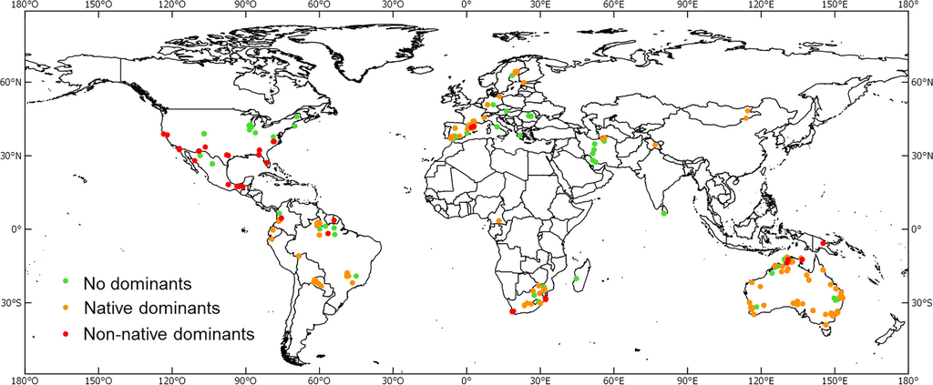

**Figure 1**

World map showing the 1293 independent study plots with no dominant ants (green circles), native (yellow circles), or non‐native dominants (red circles). Many of the study plots were conducted in independent locations in relatively close proximity, so appear as a single plot

### 2.2 Defining behavioral dominance and invasive (non‐native) species

We focused on the relationship between diversity and behavioral dominance, rather than simply numerical dominance, because this is specified in the dominance‐impoverishment rule. At any rate, in those sites where behaviorally dominant species occurred, the abundance of behaviorally dominant species was highly correlated with the abundance of the most abundant species (Spearman *r* = 0.96, *p* < 0.0001, *n* = 645), i.e., behavioral and numerical dominance was highly correlated. We considered a species to be behaviorally dominant based on both aggressive behavior and effects on other species by excluding them from near their nests and from high‐value food resources (Andersen, 1992; Cerdá et al., 2013; Savolainen et al., 1989; Vepsäläinen & Pisarski, 1982). Behaviorally dominant species are thus defined as highly aggressive species that usually predominate numerically, occupy large territories, and have mutually exclusive distribution patterns at local scales. Given the large number of studies use, data are not available to demonstrate impact by dominant species in each of our study communities, and so we had to rely on a priori classifications of taxa based on the literature and our combined expert knowledge. The following taxa were thus classified as behaviorally dominant (Appendix S1): *Anonychomyrma, Anoplolepis*, *Azteca*, *Dorymyrmex* (except *insana* group), *Formica* (only *exsecta* and *rufa* groups), *Froggattella*, *Iridomyrmex*, *Linepithema*, *Liometopum*, *Oecophylla*, *Papyrius*, *Pheidole* (only *megacephala* and *fallax* groups), *Philidris*, *Solenopsis* (subgenus *Solenopsis*, i.e., “fire ants”), *Tapinoma* (*nigerrimum* group), and *Wasmannia auropunctata*. There is considerable empirical evidence that species in these taxa are behaviorally dominant and influence the structure and dynamics of local ant communities (e.g., Andersen, 1995, 1997a; Arnan et al., 2011; Bertelsmeier, Avril, et al., 2015; Cerdá et al., 2013; Lach & Hooper‐Bùi, 2010; Savolainen et al., 1989). Some species from other genera (e.g., *Crematogaster*) might also be good candidates, but the distribution of behavioral dominance among constituent species groups is poorly known, and so they have not been included. Army‐ants (subfamily Dorylinae) were also not included. These species are behavioral dominant species, but their effects on other ant species are temporally limited given their nomadic life style.

Our pool of behaviorally dominant species included five invasive (non‐native) species occurring in our communities outside their native ranges: the yellow crazy ant (*Anoplolepis gracilipes*), the Argentine ant (*Linepithema humile*), the big‐headed ant (*Pheidole megacephala*), fire ants (*Solenopsis* spp., subgenus *Solenopsis*), and the electric ant (*Wasmannia auropunctata)* (Bertelsmeier, Blight, & Courchamp, 2016; Bertelsmeier, Luque, Hoffmann, & Courchamp, 2015; Bertelsmeier, Avril, et al., 2015; Lach & Hooper‐Bùi, 2010). These species are considered the five top invasive ants (Bertelsmeier et al., 2016) and are on the list of the “100 of the world's worst invasive alien species” (Lowe, Browne, Boudjelas, & de Poorter, 2000).

### 2.3 Climatic characterization of sites

We selected two climatic variables that are consistently related to variation in ant communities globally (e.g., Arnan, Cerdá, & Retana, 2014; Dunn et al., 2009; Gibb et al., 2015; Jenkins et al., 2011): mean annual temperature (hereafter, temperature) and annual precipitation (hereafter, precipitation). We acknowledge that other aspects of climate such as seasonality can have an important influence on ant communities, but there is no evidence that they are key drivers of ant diversity at a global scale. For each locality, temperature and precipitation information was obtained for the period 1950–2000 from the WORLDCLIM database (http://www.worldclim.org/bioclim) using rasters with the highest available resolution (30 arc‐s, approx. 1 × 1 km). Such a resolution provides climatic data that are directly applicable to the scale of sampling in our study communities (approximately 1 ha).

### 2.4 Data analyses

All analyses were performed in R v.3.2.4 statistical environment (R Core Team, 2016). We initially determined that temperature and precipitation were significantly but not highly correlated (Spearman *r* = 0.27, *p* < 0.0001), so both variables were retained for analyses.

We considered behavioral dominance at two levels: the (a) occurrence (presence‐absence) and (b) abundance of dominant species in a site. Occurrence data were considered for all 1,293 sites, whereas abundance data were considered only for those 645 sites where behaviorally dominant species occurred and where abundance data were available, in order to remove the effects of a high proportion of zeros. Abundance of behaviorally dominant species was computed as a proportion of total individuals sampled for all species combined.

We used two general linear mixed models (GLMMs) to test how behavioral dominance and climate relate to ant species richness. The first model used occurrence of dominant species (sites with vs. sites without dominants), temperature and precipitation as explanatory variables with ln‐transformed species richness as the response variable (‘Global occurrence model’, Table 1). The second model used abundance of dominant species, temperature and precipitation as explanatory variables with ln‐transformed species richness as the response variables (‘Global abundance model’, Table 1). The abundance model also included the quadratic term of abundance, in case the relationship was unimodal (Andersen, 1992; Parr, 2008; Parr et al., 2005). To compare dominance‐diversity relationships under native vs. non‐native dominant species and along climate gradients, we first classified sites into three categories: “sites without dominants”, “sites with native dominants”, and “sites with non‐native dominants” (our dataset included no sites with both native and non‐native dominants). We then tested the relationship between the interaction of dominant type (no dominants, native dominants, non‐native dominants) and the climatic variables (temperature and precipitation) on species richness (ln‐transformed) by using a GLMM (‘Dominants type × climate model’, Table 1). We also analyzed the relationship between the abundance of native and non‐native dominant ants and species richness (ln‐transformed) in separate GLMM models (‘Native dominants × climate model’; and ‘Non‐native dominants × climate model’; Table 1). Both models included the interaction of the abundance of dominant ants and its quadratic term with the climatic variables (temperature and precipitation) as explanatory variables.

Table 1. Summary of the best‐supported models analyzing the dominance–diversity relationship as well as the relationship between climate and behavioral dominance from different datasets. A reference name for each complete model, the variables included in each complete model, the variables included within the best‐fitted models, the range of the marginal and conditional *R*<sup>2</sup> values for the best‐fitted models and the number of sites used for each analysis are shown

| Model name | Complete model | Variables selected | *R* <sup>2</sup> <sub>marginal/conditional</sub> | *N* sites |
| --- | --- | --- | --- | --- |
| Effects on species richness |  |  |  |  |
| Global occurrence model | S = BD + MAT + AP + cov | BD + MAT + Hemisphere | 0.29–0.34/0.66–0.68 | 1293 |
| Global abundance model | S = RAB + RAB<sup>2</sup> + MAT + AP + cov | RAB + RAB<sup>2</sup> + Hemisphere | 0.12–0.20/0.72 | 645 |
| Dominants type × climate model | S = DTxMAT + DTxAP + DTxMATxAP + cov | DTxMAT | 0.35/0.69 | 1293 |
| Native dominants × climate model | S = RABxMAT + RABxAP + RABxMATxAP + RAB<sup>2</sup>xMAT + RAB<sup>2</sup>xAP + RAB<sup>2</sup>xMATxAP + cov | RAB<sup>2</sup> + Continent + Hemisphere | 0.04–0.17/0.72–0.74 | 523 |
| Non‐native dominants × climate model | S = RABxMAT + RABxAP + RABxMATxAP + RAB<sup>2</sup>xMAT + RAB<sup>2</sup>xAP + RAB<sup>2</sup>xMATxAP + cov | RAB + RAB<sup>2</sup> + Habitat type + Hemisphere | 0.17–0.21/0.80–0.84 | 122 |
| Effects on relative abundance of dominant species |  |  |  |  |
| Climate model of native dominants | RAB = MAT + MAT<sup>2</sup> + AP + MATxAP + cov | MAT + MAT<sup>2</sup> + AP + Continent + Habitat type + Hemisphere | 0.31–0.37/0.54–0.59 | 523 |
| Climate model of non‐native dominants | RAB = MAT + MAT<sup>2</sup> + AP + MATxAP + cov | Continent + Habitat type + Hemisphere | 0.11–0.12/0.41–0.44 | 122 |

### Note

- All complete models included a set of covariates (cov: Continent, Hemisphere, Habitat type, Pitfall days, and Transect length).
- BD, Behavioral dominance (two levels: sites without dominants and sites with dominants); DT, Dominance type (three levels: sites without dominants, sites with native dominants, and sites with non‐native dominants); MAT, Mean annual temperature; AP, Annual precipitation; RAB, Relative abundance of dominant ants; and S, Species richness.

Finally, we analyzed how climate variables shape the relative abundance of native and non‐native dominant species in two separate models where only the sites where dominants occurred and with available abundance data were used (‘Climate model of native dominants’ and ‘Climate model of non‐native dominants’, Table 1). In both models, the explanatory variables were temperature, precipitation, and their interaction, and the abundance of native and non‐native dominants species (logit transformed) were the response variables, respectively. All models included a set of covariates as fixed variables that were used to control for variation in sampling effort (number of trap days and transect length), region (continent and hemisphere), and habitat structural type (forest or open habitat).

We used mixed‐effects models because sites were spatially clustered. Thus, clusters of sites separated by no more than 100 km from each other were represented by a single random effect to control for potential autocorrelation between localized sites (see Gibb et al., 2015) while allowing the direct comparison between sites from nearby locations. The mixed‐effect models (GLMMs) were fitted with the *lme* function in *lme4* package in R. Akaike's information criterion with a correction for finite sample sizes (AICc) was used to select the best‐supported models (Burnham & Anderson, 2002). In each analysis, models were constructed using all combinations of explanatory variables. The best‐supported models for each analysis were selected based on the AICc weights, which reveal the relative likelihood of a given model—based on the data and the fit—scaled to one; thus, models with a delta (AICc difference) <2 were selected (Burnham & Anderson, 2002). We selected as relevant variables those that were included in the best‐supported models. The model selection procedure was conducted using the *dredge* function in the MuMIn package in R. Both marginal and conditional *R*<sup>2</sup> values of the best‐supported models (which give the variation explained by fixed as well as fixed + random effects, respectively) were reported (Nakagawa & Schielzeth, 2013).

## 3 RESULTS

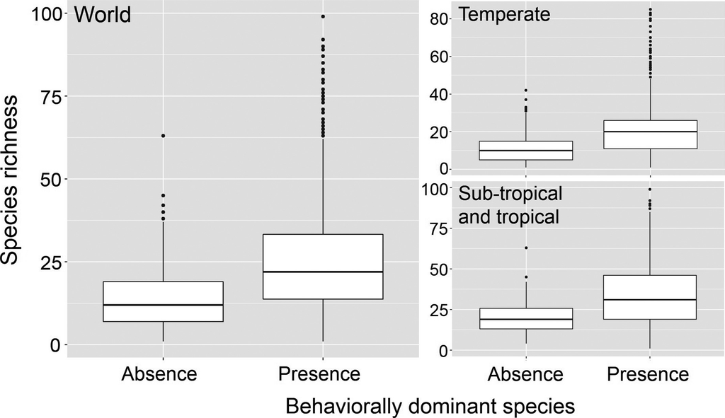

**Figure 2**

Relationship between ant species richness and the presence or absence of behaviorally dominant species in the world, and separated by temperate and subtropical and tropical latitudes

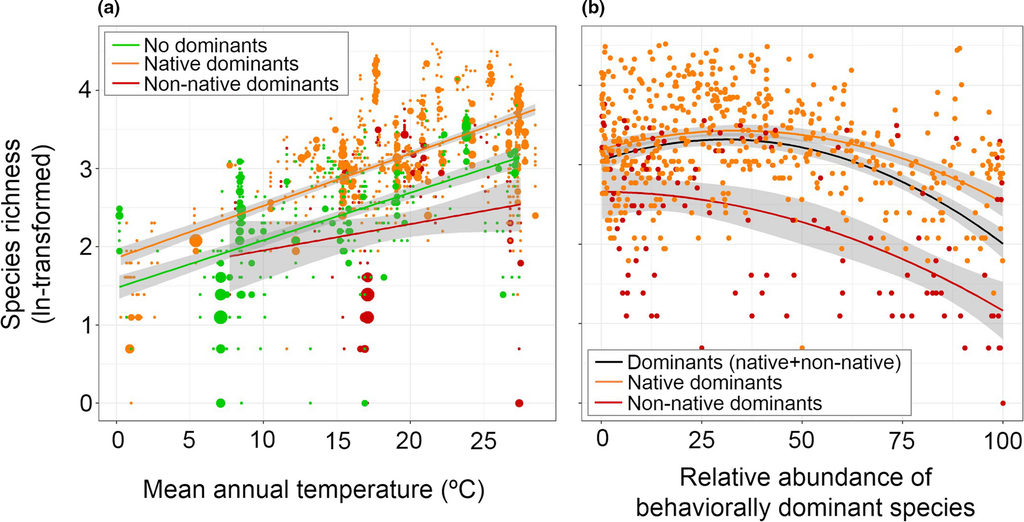

**Figure 3**

At sites where dominant species occurred and where abundance data were available, there was a unimodal relationship between species richness and the abundance of behaviorally dominant species (Table 1, ‘Global abundance model’), with a very shallow ascending side of the curve but steeper descent (Figure 3b, *R*<sup>2</sup><sub>marginal/conditional</sub>=0.20/0.72). Species richness was not only lower when non‐native species were present relative to when they were absent but it also declined at a faster rate as their relative abundance increased (Table 1, ‘Native dominants × climate’ and ‘Non‐native dominants × climate’ models, Figure 3b). In both cases, there was no interaction between relative abundance of dominant species and either temperature or precipitation (Table 1, ‘Native dominants × climate’ and ‘Non‐native dominants × climate’ models). The relative abundance of non‐native dominant species was not related to either temperature or precipitation, whereas that of native dominant species was related to both (Table 1, ‘Climate model of non‐native dominants’ and ‘Climate model of native dominants’). There was a very shallow U‐shaped relationship between the relative abundance of native dominants and temperature (Figure 4a), with the relative abundance of dominants tending to be highest at the lowest and highest temperatures. The relative abundance of native dominant ants was negatively related to precipitation (Figure 4b).

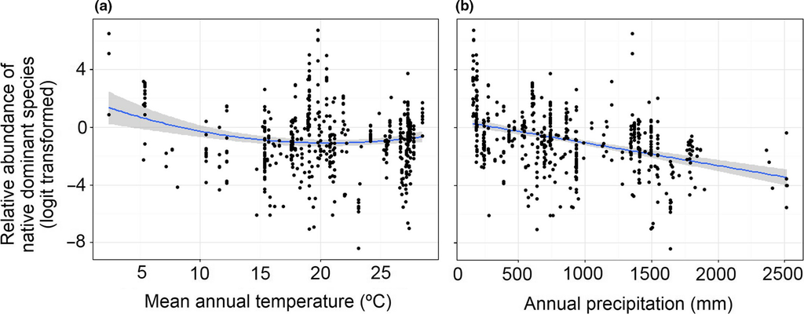

**Figure 4**

Relationships between mean annual temperature (a) and annual precipitation (b) with the relative abundance (logit transformed) of native dominant species. Shaded area represents the standard error [Colour figure can be viewed at [wileyonlinelibrary.com](http://wileyonlinelibrary.com/)]

## 4 DISCUSSION

In nearly 1,300 local ant assemblages distributed across five continents, we found that where dominant species occurred and abundance data were available, the relationship between dominance and richness is humped‐shaped. Such a relationship parallels models of the control of diversity in communities of plants and sessile intertidal organisms along gradients of resource availability (Grime, 1973), productivity (Tilman, 1982), or disturbance (Connell, 1978). A premise in these models is that diversity initially increases with environmental favorability but then decreases as conditions allow highly competitive species to become so dominant that they exclude other species. Such a unimodal relationship has been documented in ants sampled at very localized food resources in a variety of local communities (Andersen, 1992; Campbell, Fellowes, & Cook, 2015; Parr et al., 2005). However, there is only limited evidence that competitive exclusion from local food resources scales up to exclusion at the site level (e.g., Baccaro et al., 2012; Gibb & Hochuli, 2004; Parr, 2008).

What causes the descending side of the dominance‐diversity curve? It cannot necessarily be attributed to competitive exclusion because the humped model applies specifically to local communities, and at larger scales there are confounding effects of climatic drivers of ant diversity. For example, if communities corresponding to very high levels of behavioral dominance associated with very low levels of species richness are from low‐diversity systems (e.g., *Formica*‐dominated communities from boreal forests), then this is not evidence of competitive exclusion in highly diverse systems. Indeed, our analysis shows many examples of very high diversity occurring with very high levels of behavioral dominance, and when native dominant species were present, species richness was actually higher than at sites without dominant species. The dominance‐impoverishment ‘rule’ is clearly not a general one.

The extent to which the dominance–diversity relationships that we have reported are causal is unclear. The association between the occurrence of non‐native dominant species and lower species richness can at least partly be explained by competitive exclusion, given that the elimination of native species by invasive invaders has been well demonstrated (Holway et al., 2002; Lach & Hooper‐Bùi, 2010; Stuble, Chick, Rodriguez‐Cabal, Lessard, & Sanders, 2013). This is consistent with our finding that the association of non‐native dominant ants with lower diversity increased with temperature, given that the effects of competition typically increase with increasing productivity (Andersen, 1995, 1997a; Grime, 1979; Rees, 2013), and productivity in ants is strongly related to temperature (Andersen, 1995).

There are alternative explanations for the association of native dominant species with higher species richness. The most parsimonious explanation is that species richness and the abundance of native dominant species show parallel responses to increasing climatic favorability (Andersen, 1995). We found a positive relationship between temperature and ant species richness, and native dominant species occupy sites with higher temperature compared to sites without dominant species. However, we found that species richness tends to be higher in sites with dominant species than those without dominant species, regardless of temperature. Moreover, if habitat favorability alone is at work, we would expect parallel responses of species richness and the abundance of native dominants to mean annual temperature, but this was not the case (species richness increased linearly along the temperature gradient, but the abundance of dominant species followed a U‐shaped relationship with temperature). The best‐supported climate model of native dominants kept most covariates, suggesting that native dominants may be responding differently depending on the continent, hemisphere and habitat type.

An alternative explanation is that dominant species actually promote species richness. Such facilitation might be through increased heterogeneity and resource availability, as suggested by Gibb (2011) for northern Europe in a study at the regional scale in boreal forests. Although Gibb (2011) found facilitation by dominant ants in the most disturbed (least productive) sites, we found that the presence of native dominant species had the greatest impact on species richness at warm (i.e., more productive) sites. Our results are consistent with the finding that facilitation occurs primarily at the most productive sites (Golberg, Rajaniemi, Gurevitch, & Stewart‐Oaten, 1999). An alternative mechanism for facilitation of species richness by dominant species is that they moderate the suppressive effect of subdominant species on subordinate species (Arnan et al., 2011). Further experimental work (see below) is required to clarify the causal mechanism(s) behind the positive relationship between species richness and the abundance of dominant species.

Why might non‐native dominant species have a negative effect on local species richness when native dominant species do not? One explanation is a lack of coevolution between invasive and native species, such that native species lack the particular compensatory mechanisms (e.g., niche partitioning, thermal tolerance‐behavioral dominance trade‐offs) that would allow coexistence (Cerdá et al., 2013). In noninvaded areas, dominant and nondominant species have evolved together and different compensatory mechanisms that allow coexistence have arisen; facilitation processes might even promote stable coexistence among species (Hart & Marshall, 2013). It is also worth mentioning that invasion and species richness suppression by invasive ant species has not been recorded for high‐diversity systems with high levels of behavioral dominance of native species, that is, invasion and exclusion might only occur in communities that are ‘naïve’ to dominance. Another explanation relates to differences in social structure between native and non‐native dominants: unlike many native species, invasive populations are often unicolonial (a population of ants inhabiting a single large polydomous colony), and so there is little or no aggression between workers from different nests (Holway et al., 2002; Passera, 1994; Robinson, 2014). Notably, *Linepithema humile* is entirely unicolonial in its introduced range, but often is not in its native range (Giraud, Pedersen, & Keller, 2002). Such a difference in social structure might have a major role in shifting competition for resources from intraspecific (in multicolonial species of native dominant species) to interspecific (in unicolonial species of invasive dominant species), and thus potentially exerting a greater effect on local species richness.

The mechanisms underlying the dominance–diversity relationships we have reported are best tested through experimental manipulation of dominant ants (Gibb & Johansson, 2011). However, experimental removals or additions of dominant species (either native or non‐native) have shown conflicting results, variably showing positive (Gibb, 2011), negative (Blinova, 2011; Gibb, 2011; King & Tschinkel, 2008), or neutral (Andersen & Patel, 1994; Gibb & Hochuli, 2004; Gibb & Johansson, 2011; King & Tschinkel, 2006, 2013) effects on species richness. This suggests the effects of dominant species on species richness might depend on biotic (e.g., whether dominant species are native or non‐native) and abiotic conditions (e.g., climate or habitat structure), as well as the interaction between them.

If our results really are caused by interactions between dominant ants and the rest of the community, then this implies that biotic interactions (competition and possibly also facilitation) can be important drivers of diversity patterns at macroecological as well as local scales (Slingsby & Verboom, 2006; Stubbs & Wilson, 2004). We call for revisiting macroecological studies that present environmental constraints as drivers of spatial patterns of diversity at large spatial scales when these studies were unable to distinguish environmental filtering from the outcome of biotic interactions. For instance, the effects of environmental favorability on species richness might be severely under‐ or overestimated in areas where non‐native or native dominant species occur, respectively. Our results also raise serious concerns relating to some key drivers of global change. Economic globalization is triggering an exponential increase in the number of introductions of exotic species (Butchart et al., 2010; Essl et al., 2011), and climate change is predicted to promote a proliferation of several non‐native dominant ant species (Bertelsmeier, Luque, et al., 2015). Our findings suggest that reductions in ant diversity by dominant species will be greatest under a combination of highest temperatures with highest occurrence of non‐native ant species, and the frequency of this scenario is likely to increase under global change.

In conclusion, we have shown that dominance‐diversity relationships in ant communities vary markedly depending on whether dominant species are native or non‐native. In particular, the association of high levels of behavioral dominance with low species richness that is often observed in invaded communities does not typically occur in native communities. Indeed, species richness in communities with native dominant species is consistently higher than in communities lacking dominant species. The dominance‐impoverishment rule appears to be restricted to invaded communities, and we propose a ‘dominance‐diversification rule’ for native communities.

Such dominance‐diversification appears to be peculiar to ants. Although ants have many parallels with plants in that both are central‐place foragers with complex foraging modules, in plant communities both native and non‐native dominant species exert negative influences on species diversity (Grime, 1973; Pyšek et al., 2012). As central‐place foragers, dominant ants cannot persistently monopolize key resources within their foraging territories in the comprehensive way that dominant plants can. Canopy trees, for instance, can comprehensively monopolize key plant resources such as light, providing no opportunity for the sort of temporal or fine‐scale spatial niche differentiation, variable outcomes of competition, or forager priority effects that facilitate species coexistence in ant communities (Andersen, 2008). However, the dominance‐diversification rule might apply to other mobile animal groups that, like ants, are organized in complex behavioral dominance hierarchies (i.e., hummingbirds, fishes, lizards) (Des Granges, 1979; Werner, 1976), and further research is needed to test the applicability of this rule among other faunal taxa.

## ACKNOWLEDGEMENTS

X.A. was supported by a Ramón y Cajal research contract by the Spanish Ministry of Economy and Competitiveness (RYC‐2015‐18448) and by the Conselho Nacional de Desenvolvimento Científico e Tecnológico of Brazil (CNPq PDS‐167533/2013‐4 and PDS‐165623/2015‐2). P.K., J.M. and M.J. were supported by the Czech Science Foundation (14‐36098G), European Research Council (GA669609), and Czech Academy of Sciences (FNRS‐17‐04). T.M.F. was supported by the Czech Science Foundation (16‐09427S). M.P. was supported by the German Academic Exchange Service (DAAD, D 10 00351). Financial support from the German Academic Exchange Service (DAAD) for the PhD study of O.P. in Germany is gratefully acknowledged. J.L.P.S was supported by the Fundação de Amparo à Pesquisas do Estado do Amazonas (FAPEAM FIXAM/AM 062.01325/2014).

## Citing Literature

[figure not shown]

[Volume24, Issue10](https://onlinelibrary.wiley.com/toc/13652486/2018/24/10)

October 2018

Pages 4614-4625

### Details

[figure not shown]

### Research funding

  - Ramón y Cajal research contract by the Spanish Ministry of Economy and Competitiveness. Grant Number: RYC‐2015‐18448
  - Conselho Nacional de Desenvolvimento Científico e Tecnológico of Brazil. Grant Numbers: PDS‐167533/2013‐4, PDS‐165623/2015‐2
  - Czech Science Foundation. Grant Numbers: 14‐36098G, 16‐09427S
  - European Research Council. Grant Number: GA669609
  - Czech Academy of Sciences. Grant Number: FNRS‐17‐04
  - German Academic Exchange Service (DAAD). Grant Number: D 10 00351
  - Fundação de Amparo à Pesquisas do Estado do Amazonas. Grant Number: FAPEAM FIXAM/AM 062.01325/2014

### Keywords

  - ants
  - [behavioral dominance](https://onlinelibrary.wiley.com/action/doSearch?field1=Keyword&text1=behavioral%20dominance)
  - coexistence
  - [dominance‐impoverishment rule](https://onlinelibrary.wiley.com/action/doSearch?field1=Keyword&text1=dominance%E2%80%90impoverishment%20rule)
  - [global scale](https://onlinelibrary.wiley.com/action/doSearch?field1=Keyword&text1=global%20scale)
  - [invasive species](https://onlinelibrary.wiley.com/action/doSearch?field1=Keyword&text1=invasive%20species)
  - precipitation
  - [species richness](https://onlinelibrary.wiley.com/action/doSearch?field1=Keyword&text1=species%20richness)
  - temperature